# Introduction to Python Project : FoodHub Data Analysis

## Context

The number of restaurants in New York is increasing day by day. Lots of students and busy professionals rely on those restaurants due to their hectic lifestyles. Online food delivery service is a great option for them. It provides them with good food from their favorite restaurants. A food aggregator company FoodHub offers access to multiple restaurants through a single smartphone app.

The app allows restaurants to receive a direct online order from a customer. The app assigns a delivery person from the company to pick up the order after it is confirmed by the restaurant. The delivery person then uses the map to reach the restaurant and waits for the food package. Once the food package is handed over to the delivery person, he/she confirms the pick-up in the app and travels to the customer's location to deliver the food. The delivery person confirms the drop-off in the app after delivering the food package to the customer. The customer can rate the order in the app. The food aggregator earns money by collecting a fixed margin on the delivery order from the restaurants.

## Objective

The food aggregator company has stored the data of the different orders made by the registered customers in their online portal. They want to analyze the data to get a fair idea about the demand of different restaurants which will help them in enhancing their customer experience. Suppose you are hired as a Data Scientist in this company and the Data Science team has shared some of the key questions that need to be answered. Perform the data analysis to find answers to these questions that will help the company improve its business.

### Data Dictionary

The data includes various information related to a food order. A detailed data dictionary is provided below.

- order_id: Unique ID of the order
- customer_id: ID of the customer who ordered the food
- restaurant_name: Name of the restaurant
- cuisine_type: Cuisine ordered by the customer
- cost_of_the_order: Cost of the order
- day_of_the_week: Indicates whether the order is placed on a weekday or weekend (The weekday is from Monday to Friday and the weekend is Saturday and Sunday)
- rating: Rating given by the customer out of 5
- food_preparation_time: Time (in minutes) taken by the restaurant to prepare the food. This is calculated by taking the difference between the timestamps of the restaurant's order confirmation and the delivery person's pick-up confirmation.
- delivery_time: Time (in minutes) taken by the delivery person to deliver the food package. This is calculated by taking the difference between the timestamps of the delivery person's pick-up confirmation and drop-off information.

### Let us start by importing the required libraries

```python
# Library for ignoring warnings
import warnings
warnings.filterwarnings('ignore')

# Libraries for reading and manipulating data
import numpy as np
import pandas as pd

# Library for data visualization
import matplotlib.pyplot as plt
import seaborn as sns
```

### Understanding the structure of the data

```python
# mount drive
from google.colab import drive
drive.mount('/content/drive')
```

```python
# Display upto two decimal points
pd.set_option('display.float_format', '{:,.2f}'.format)

# Loading data as pandas dataframe
path = '/content/drive/MyDrive/AI & ML Course/Introduction to Python/Project/foodhub_order.csv'
data = pd.read_csv(path)

# creating a copy of data
df = data.copy()
```

```python
# Examining first 5 records of data
df.head()
```

|  | order_id | customer_id | restaurant_name | cuisine_type | cost_of_the_order | day_of_the_week | rating | food_preparation_time | delivery_time |
| --- | --- | --- | --- | --- | --- | --- | --- | --- | --- |
| 0 | 1477147 | 337525 | Hangawi | Korean | 30.75 | Weekend | Not given | 25 | 20 |
| 1 | 1477685 | 358141 | Blue Ribbon Sushi Izakaya | Japanese | 12.08 | Weekend | Not given | 25 | 23 |
| 2 | 1477070 | 66393 | Cafe Habana | Mexican | 12.23 | Weekday | 5 | 23 | 28 |
| 3 | 1477334 | 106968 | Blue Ribbon Fried Chicken | American | 29.20 | Weekend | 3 | 25 | 15 |
| 4 | 1478249 | 76942 | Dirty Bird to Go | American | 11.59 | Weekday | 4 | 25 | 24 |

### **Question 1:** How many rows and columns are present in the data? [0.5 mark]

```python
# checking the shape of data
df.shape

print(f'The dataset has {df.shape[0]} rows and {df.shape[1]} columns.')
```

```
The dataset has 1898 rows and 9 columns.
```

#### Observations:

- The dataset has 1898 records with 9 different attributes.

### **Question 2:** What are the datatypes of the different columns in the dataset? (The info() function can be used) [0.5 mark]

```python
# checking datatypes of different columns
df.info()

# get all data types
all_dtypes = df.dtypes

# counting the occurrences of each data type
object_count = (all_dtypes == 'object').sum()
int_count = (all_dtypes == 'int').sum()
float_count = (all_dtypes == 'float').sum()

print('-'*75)
print(f'The dataset is comprised of {object_count} object, {int_count} integer and {float_count} float data types.')
```

```
<class 'pandas.core.frame.DataFrame'>
RangeIndex: 1898 entries, 0 to 1897
Data columns (total 9 columns):
 #   Column                 Non-Null Count  Dtype
---  ------                 --------------  -----
 0   order_id               1898 non-null   int64
 1   customer_id            1898 non-null   int64
 2   restaurant_name        1898 non-null   object
 3   cuisine_type           1898 non-null   object
 4   cost_of_the_order      1898 non-null   float64
 5   day_of_the_week        1898 non-null   object
 6   rating                 1898 non-null   object
 7   food_preparation_time  1898 non-null   int64
 8   delivery_time          1898 non-null   int64
dtypes: float64(1), int64(4), object(4)
memory usage: 133.6+ KB
---------------------------------------------------------------------------
The dataset is comprised of 4 object, 4 integer and 1 float data types.
```

#### Observations:

- There are 9 columns out of which 4 columns were of 'integer' data type, 4 columns were of 'object' data type and 1 column is of 'float' data type.
- The order_id, customer_id, food_preparation_time and delivery_time were in 'integer' data type.
- The retaurant_name, cuisine_type and day_of_the_week were in 'object' data type.
- cost_of_the_order is in 'float' data type.
- The rating is in 'object' data type. But in general it should be of integer or float data type the reason might be that either some missing values were in the dataset or some customers had not given rating.

### **Question 3:** Are there any missing values in the data? If yes, treat them using an appropriate method. [1 mark]

```python
# checking for null values
null_val = df.isnull().sum()

print(f'There are {null_val[1]} missing values')
print('-'*50)
null_val
```

```
There are 0 missing values
--------------------------------------------------
```

|  | 0 |
| --- | --- |
| order_id | 0 |
| customer_id | 0 |
| restaurant_name | 0 |
| cuisine_type | 0 |
| cost_of_the_order | 0 |
| day_of_the_week | 0 |
| rating | 0 |
| food_preparation_time | 0 |
| delivery_time | 0 |

**dtype:** int64

```python
# unique values in rating column
df['rating'].unique()
```

```
array(['Not given', '5', '3', '4'], dtype=object)
```

#### Observations:

- There are no missing values in the dataset, therefore treating of missing values is not required. But few customers had not given rating.

### **Question 4:** Check the statistical summary of the data. What is the minimum, average, and maximum time it takes for food to be prepared once an order is placed? [2 marks]

```python
# statistical summary of the data
stat_summary = df.describe().T

# Minimum, maximum and mean time taken for preparing food
min_time_food = df['food_preparation_time'].min()
max_time_food = df['food_preparation_time'].max()
mean_time_food = df['food_preparation_time'].mean()

print(f'For preparing food the minimum time taken is {min_time_food} minutes, maximum time taken is {max_time_food} minutes, and average time taken is {mean_time_food:.2f} minutes.')
print('-'*150)
stat_summary
```

```
For preparing food the minimum time taken is 20 minutes, maximum time taken is 35 minutes, and average time taken is 27.37 minutes.
------------------------------------------------------------------------------------------------------------------------------------------------------
```

|  | count | mean | std | min | 25% | 50% | 75% | max |
| --- | --- | --- | --- | --- | --- | --- | --- | --- |
| order_id | 1,898.00 | 1,477,495.50 | 548.05 | 1,476,547.00 | 1,477,021.25 | 1,477,495.50 | 1,477,969.75 | 1,478,444.00 |
| customer_id | 1,898.00 | 171,168.48 | 113,698.14 | 1,311.00 | 77,787.75 | 128,600.00 | 270,525.00 | 405,334.00 |
| cost_of_the_order | 1,898.00 | 16.50 | 7.48 | 4.47 | 12.08 | 14.14 | 22.30 | 35.41 |
| food_preparation_time | 1,898.00 | 27.37 | 4.63 | 20.00 | 23.00 | 27.00 | 31.00 | 35.00 |
| delivery_time | 1,898.00 | 24.16 | 4.97 | 15.00 | 20.00 | 25.00 | 28.00 | 33.00 |

### **Question 5:** How many orders are not rated? [1 mark]

```python
# orders that are not rated
not_rated = df['rating'].value_counts().reset_index()

print(f'Almost {not_rated.iloc[0, 1]} customers had {not_rated.iloc[0, 0]} rating')
print('-'*50)
not_rated
```

```
Almost 736 customers had Not given rating
--------------------------------------------------
```

|  | rating | count |
| --- | --- | --- |
| 0 | Not given | 736 |
| 1 | 5 | 588 |
| 2 | 4 | 386 |
| 3 | 3 | 188 |

#### Observations:

- Almost 40% of the customers had not given rating.
- There were no ratings of 0, 1 and 2. It might indicate customers were satisfied with the services provided.
- Actions need to be taken for converting customers who had not rated for the services.

### Exploratory Data Analysis (EDA)

### **Question 6:** Explore all the variables and provide observations on their distributions. (Generally, histograms, boxplots, countplots, etc. are used for univariate exploration.) [9 marks]

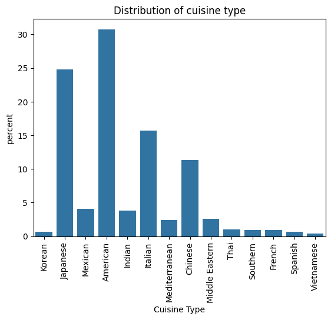

```python
# Examining different cuisines
sns.countplot(df, x='cuisine_type', stat='percent')
plt.xticks(rotation=90)
plt.xlabel('Cuisine Type')
plt.title('Distribution of cuisine type')
plt.show()
```

#### Observations:

- The cuisine type ordered by most of the customers were American(almost 31%) followed by Japanese(almost 25%), Italian(almost 15%) and Chinese(almost 11%). Vietnamese(almost 1%) is the least ordered cuisine type.

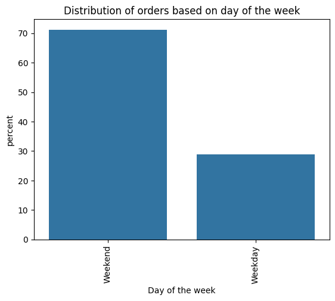

```python
# observations of orders based on day of the week
sns.countplot(df, x='day_of_the_week', stat='percent')
plt.xticks(rotation=90)
plt.xlabel('Day of the week')
plt.title('Distribution of orders based on day of the week')
plt.show()
```

#### Observations:

- Almost 71% of orders were placed during weekend and 29% of orders were placed during weekday.

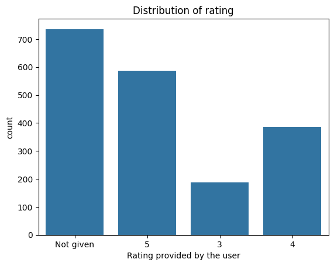

```python
# Observing the ratings provided by the user
sns.countplot(df, x='rating')
plt.xlabel('Rating provided by the user')
plt.title('Distribution of rating')
plt.show()
```

#### Observations:

- Most of the customers had not given rating for the delivery they received i.e., almost 750 customer had not given rating.
- Around 580 customers had given rating of 5.
- Rating of 4 was given by 380 customers approximately.
- Approximately 180 customers had given rating of 3.
- No customer had given rating of 0, 1 and 2. May be they are satisfied with the services provided.

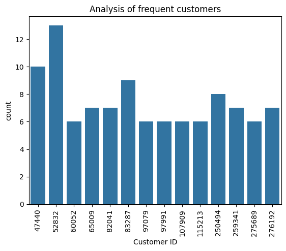

```python
# sorting customers based on their frequent orders
cust_count = df['customer_id'].value_counts().reset_index()

# customers ordered more than 5 times
fre_cust = cust_count[cust_count['count']>5]

# observations of frequent customers
sns.barplot(fre_cust, x='customer_id', y='count')
plt.xticks(rotation=90)
plt.xlabel('Customer ID')
plt.title('Analysis of frequent customers')
plt.show()
```

#### Observations:

- Almost 14 customers ordered more than 5 times.
- There are 2 customers who ordered food almost 10 times. Their customer id's were 52832 and 47440.

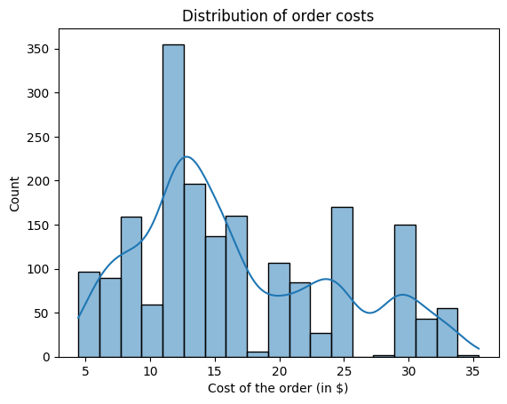

```python
# Analyzing cost of the order
sns.histplot(df, x='cost_of_the_order', kde=True)
plt.xlabel('Cost of the order (in $)')
plt.title('Distribution of order costs')
plt.show()
```

#### Observations:

- The lowest and highest cost of the orders were 5 dollars and 35 dollars respectively.
- More than 300 orders costed around 11 dollars to 12 dollars.
- 50% of the orders costing around 5 dollars to 14 dollars.
- Cost of the order is slightly right skewed.

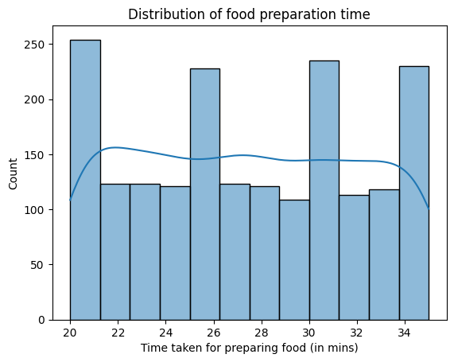

```python
# Analyzing food preparation time
sns.histplot(df, x='food_preparation_time', kde=True)
plt.xlabel('Time taken for preparing food (in mins)')
plt.title('Distribution of food preparation time')
plt.show()
```

#### Observations:

- Time taken for preparing food is not skewed highly, even it is not perfectly distributed, a slight skewness towards right.
- Almost 250 orders took 20 to 21 minutes for preparing food. Followed by 240 orders took 30 to 31 minutes.
- Least number of orders i.e., 110 orders took around 29 to 30 minutes for preparing food.

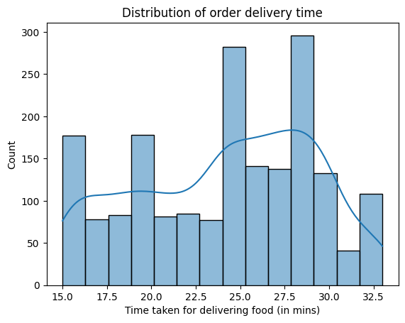

```python
# Observation on time taken for delivery
sns.histplot(df, x='delivery_time', kde=True)
plt.xlabel('Time taken for delivering food (in mins)')
plt.title('Distribution of order delivery time')
plt.show()
```

#### Observations:

- Time taken for delivering food is slightly left skewed.
- Least time taken for delivering order is around 15 to 16 minutes and around 32 minutes is the highest time taken for delivering the order.
- Almost 300 orders took 29 minutes for delivering food. Followed by 280 orders took 25 minutes.
- Least number of orders i.e., 40 orders took around 31 minutes for delivering food.

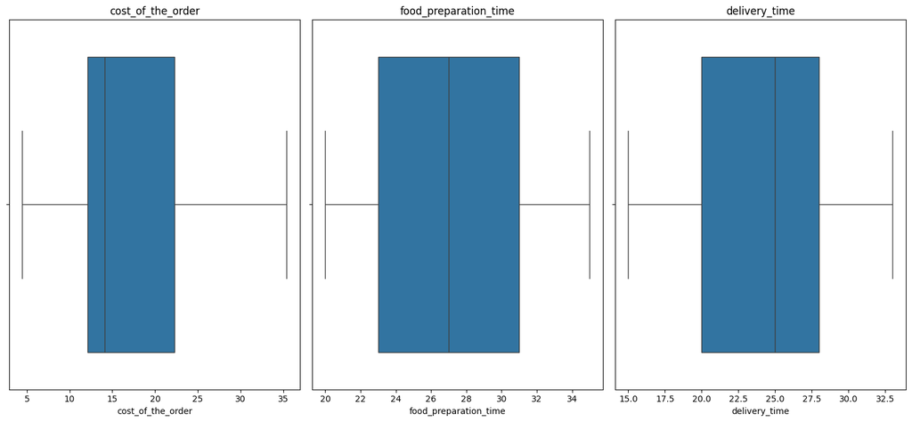

```python
# Analyzing cost_of_the_order, food_preparation_time and delivery_time using boxplot
columns = ['cost_of_the_order', 'food_preparation_time', 'delivery_time']

plt.figure(figsize=(15,7))
for i, col in enumerate(columns):
  plt.tight_layout()
  plt.subplot(1, 3, i+1)
  sns.boxplot(df, x=col)
  plt.title(col)
plt.show()
```

#### Observations:

- There are no outliers for cost of the order, food preparation time and delivery time.
- The minimum cost of the order is 5 dollars and maximum cost is 35 dollars. The median cost of the order is around 14 dollars. And the data is right skewed.
- The minimum time taken for food preparation is around 20 minutes and maximum time taken is around 35 minutes. The median time taken is around 27 minutes. And there is no skewness in the data.
- The minimum time taken for delivery is around 15 minutes and maximum time taken is around 32.5 minutes. The median time taken is around 25 minutes. And the data is left skewed.

### **Question 7**: Which are the top 5 restaurants in terms of the number of orders received? [1 mark]

```python
# extracting top 5 restaurants using groupby, count and sort_values functions
top_five_restaurants = df.groupby('restaurant_name').count().sort_values(by='order_id', ascending=False)
top_five_restaurants[0:5]
```

| restaurant_name | order_id | customer_id | cuisine_type | cost_of_the_order | day_of_the_week | rating | food_preparation_time | delivery_time |
| --- | --- | --- | --- | --- | --- | --- | --- | --- |
| Shake Shack | 219 | 219 | 219 | 219 | 219 | 219 | 219 | 219 |
| The Meatball Shop | 132 | 132 | 132 | 132 | 132 | 132 | 132 | 132 |
| Blue Ribbon Sushi | 119 | 119 | 119 | 119 | 119 | 119 | 119 | 119 |
| Blue Ribbon Fried Chicken | 96 | 96 | 96 | 96 | 96 | 96 | 96 | 96 |
| Parm | 68 | 68 | 68 | 68 | 68 | 68 | 68 | 68 |

```python
# or top 5 restaurants can be extracted using value counts
top_5 = df['restaurant_name'].value_counts().index[0:5]

print(f"The top 5 restaurants were: {', '.join(top_5)}")
```

```
The top 5 restaurants were: Shake Shack, The Meatball Shop, Blue Ribbon Sushi, Blue Ribbon Fried Chicken, Parm
```

#### Observations:

- Shake Shack, The Meatball Shop, Blue Ribbon Sushi, Blue Ribbon Fried Chicken and Parm were top 5 restaurants.
- Shake Shack and The Meatball Shop were top restaurants had received 219 and 132 orders respectively.

### **Question 8**: Which is the most popular cuisine on weekends? [1 mark]

```python
# most popular cuisine during weekends using value_counts
most_cuisine_type = df[df['day_of_the_week'] == 'Weekend']['cuisine_type'].value_counts().index[0]

print(f'{most_cuisine_type} is the most popular cuisine type')
```

```
American is the most popular cuisine type
```

#### Observations:

- American is the most popular cuisine type during weekends.

### **Question 9**: What percentage of the orders cost more than 20 dollars? [2 marks]

```python
# percentage of orders greater than 20 dollars
(df[df['cost_of_the_order'] > 20]['cost_of_the_order'].count()/df.shape[0])*100
# or
percent_of_order = (df[df['cost_of_the_order'] > 20].value_counts().count()/df.shape[0])*100
print(f'{percent_of_order:.2f}% of orders cost more than $20')
```

```
29.24% of orders cost more than $20
```

#### Observations:

- Almost 29.24% of orders cost more than 20 dollars and 70.76% of orders costs less than 20 dollars.

### **Question 10**: What is the mean order delivery time? [1 mark]

```python
# mean order delivery time
mean_delivery_time = df['delivery_time'].mean()
print(f'The mean order delivery time {mean_delivery_time:.2f} minutes')
```

```
The mean order delivery time 24.16 minutes
```

#### Observations:

- The mean order delivery time is 24.16 minutes and the maximum time taken for delivering food is 33 minutes.

### **Question 11:** The company has decided to give 20% discount vouchers to the top 3 most frequent customers. Find the IDs of these customers and the number of orders they placed. [1 mark]

```python
# top 3 frequent customers and total number of orders placed
top_3_cust = df['customer_id'].value_counts().reset_index()[:3]

# list of customer id's
top_customer_ids = top_3_cust['customer_id'].astype(str).tolist()

# list of their respective counts
top_cust_orders = top_3_cust['count'].astype(str).tolist()

print(f"The top 5 restaurants were {', '.join(top_customer_ids)} and the orders placed were {', '.join(top_cust_orders)} respectively.")
```

```
The top 5 restaurants were 52832, 47440, 83287 and the orders placed were 13, 10, 9 respectively.
```

#### Observations:

- The top 3 customer IDs are 52832, 47440 and 83287; total orders placed by these customers were 13, 10 and 9 respectively.
- Further steps need to taken by the FoodHub company to increase the customer engagement.

### **Question 12**: Perform a multivariate analysis to explore relationships between the important variables in the dataset. (It is a good idea to explore relations between numerical variables as well as relations between numerical and categorical variables) [10 marks]

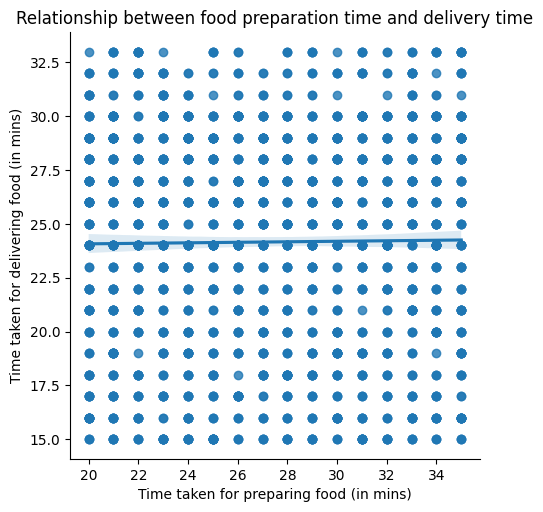

```python
# Exploring relation between food_preparation_time and delivery_time
sns.lmplot(df, x='food_preparation_time', y='delivery_time')
plt.xlabel('Time taken for preparing food (in mins)')
plt.ylabel('Time taken for delivering food (in mins)')
plt.title('Relationship between food preparation time and delivery time')
plt.show()
```

#### Observations:

- There is a slight positive relation between food preparation time and delivery time, but not strong enough.

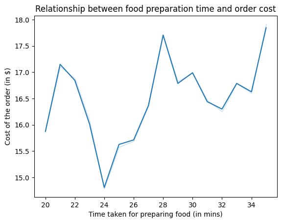

```python
# Exploring relation between food_preparation_time and cost_of_the_order
sns.lineplot(df, x='food_preparation_time', y='cost_of_the_order', ci=False)
plt.xlabel('Time taken for preparing food (in mins)')
plt.ylabel('Cost of the order (in $)')
plt.title('Relationship between food preparation time and order cost')
plt.show()
```

#### Observations:

- There is no much trend can be observed between time taken for preparing food and cost of the order.
- There are few dips and increment in trend.
- The chances might be as the volume of orders increases, we're likely to see a corresponding rise in both the total cost of those orders and the time needed for food preparation.
- The chance might be that when the number of orders goes down, we'd expect to see a proportional decrease in both the overall cost of orders and the time it takes to get food ready.

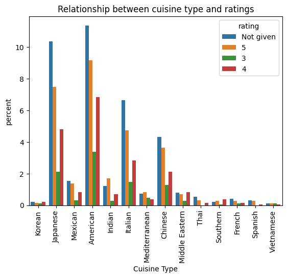

```python
# Exploring relation between cuisine_type and rating
sns.countplot(df, x='cuisine_type', hue='rating', stat='percent')
plt.xlabel('Cuisine Type')
plt.xticks(rotation=90)
plt.title('Relationship between cuisine type and ratings')
plt.show()
```

#### Observations:

- American is the most preferred cuisine type by most customers, almost 11% of the customers had not given rating, 9% of the customers had given 5 rating, followed by 4 rating given by 7% of the customers and only 3.5% of customers had given a rating of 3.
- The next preferred cuisine type is Japanese, which followed the same trend as American cuisine type but varied slightly in rating percentage i.e., 10.2% had not given rating, 7.5% had given a rating of 5, 4.5% had given a rating of 4 and 2% of the customers had given rating of 3.
- A similar trend was followed by Italian and Chinese but varied in rating percentage.

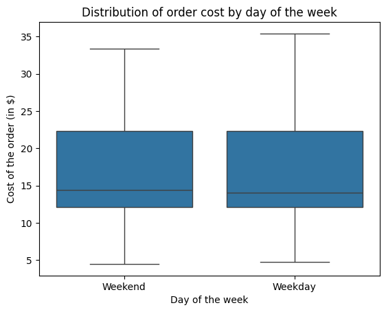

```python
# Examining the relation between day_of_the_week and cost_of_the_order
sns.boxplot(df, x='day_of_the_week', y='cost_of_the_order')
plt.xlabel('Day of the week')
plt.ylabel('Cost of the order (in $)')
plt.title('Distribution of order cost by day of the week')
plt.show()
```

#### Observations:

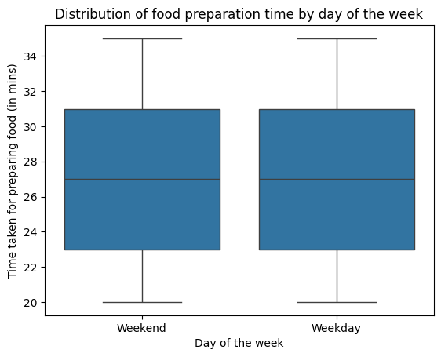

```python
# Examining the relation between day_of_the_week and food_preparation_time
sns.boxplot(df, x='day_of_the_week', y='food_preparation_time')
plt.xlabel('Day of the week')
plt.ylabel('Time taken for preparing food (in mins)')
plt.title('Distribution of food preparation time by day of the week')
plt.show()
```

#### Observations:

- There is no much difference in time taken for preparing food during weekend and weekday.
- The median time taken for preparing food during weekend and weekday is around 27 minutes.
- The minimum time taken for preparing food during weekend and weekday is approximately 20 minutes.
- The maximum time taken for preparing food during weekend and weekday is approximately 35 minutes.
- The data is not skewed and there are no outliers.

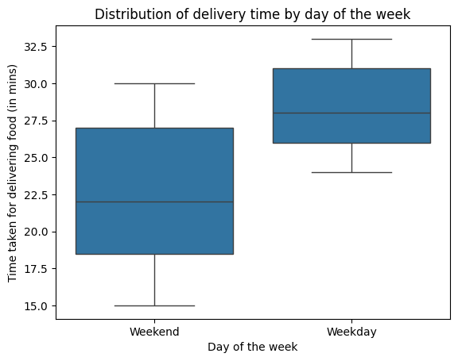

```python
# Examining the relation between day_of_the_week and delivery_time
sns.boxplot(df, x='day_of_the_week', y='delivery_time')
plt.xlabel('Day of the week')
plt.ylabel('Time taken for delivering food (in mins)')
plt.title('Distribution of delivery time by day of the week')
plt.show()
```

#### Observations:

- Time taken for delivering food during weekday is greater when compared with weekend.
- The minimum time taken for delivering food during weekend is around 15 minutes which is less when compared to the minimum time taken for delivering food during weekday which is 24 minutes.
- The maximum time taken for delivering food during weekend is around 30 minutes which is less when compared to the maximum time taken for delivering food during weekday i.e., 32.5 minutes.
- The median time taken for delivering food during weekend is around 22 minutes but during weekday it is around 28 minutes.
- There are no outliers and it is slightly right skewed.

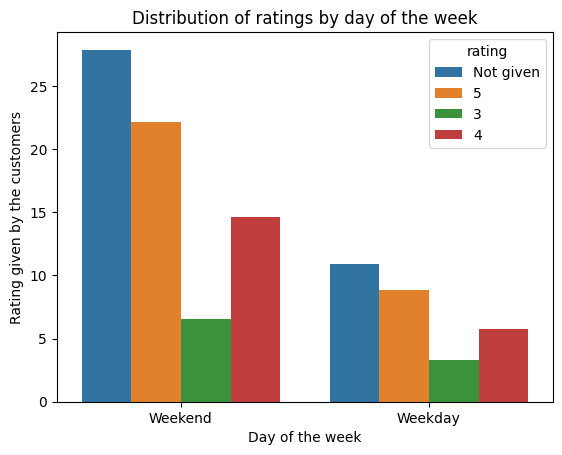

```python
# observing the relation between day_of_the_week and rating
sns.countplot(df, x='day_of_the_week', hue='rating', stat='percent')
plt.xlabel('Day of the week')
plt.ylabel('Rating given by the customers')
plt.title('Distribution of ratings by day of the week')
plt.show()
```

#### Observations:

- There are more orders during weekend when compared to the orders during weekday and almost 27% of customers had not given rating, 22% of customers had given a rating of 5, approximately 15% of customers had given a rating of 4 and around 7% of customers had given rating of 3.
- The trend of rating is same as above but the percent of customers rated for the service varied since there are few orders during weekday when compared to the orders during weekend i.e., almost 11% of customers had not given rating, 9% of customers had given a rating of 5, approximately 6% of customers had given a rating of 4 and around 3% of customers had given rating of 3.

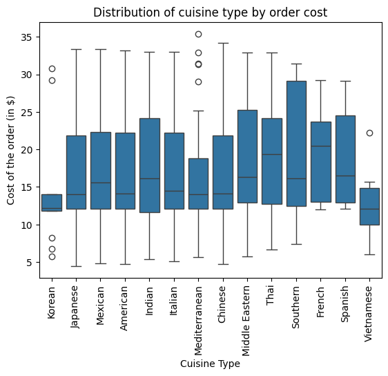

```python
# Examining the relation between cuisine_type and cost_of_the_order
sns.boxplot(df, x='cuisine_type', y='cost_of_the_order')
plt.xlabel('Cuisine Type')
plt.ylabel('Cost of the order (in $)')
plt.xticks(rotation=90)
plt.title('Distribution of cuisine type by order cost')
plt.show()
```

#### Observations:

- Out of all cuisine types Japanese has a minimum cost of the order i.e., around 4 dollars. Mediterranean is costing more i.e., 35 dollars, followed by Chinese costing around 34 dollars.
- 12 cuisine types were right skewed out of 14 and the remaining 2 were left skewed.
- Korean, Mediterranean and Vietnamese has some outliers.
- As we have noticed American is the most preferred cuisine type which has a median cost of 14 dollars, minimum cost of 5 dollars and maximum cost of 32 dollars.

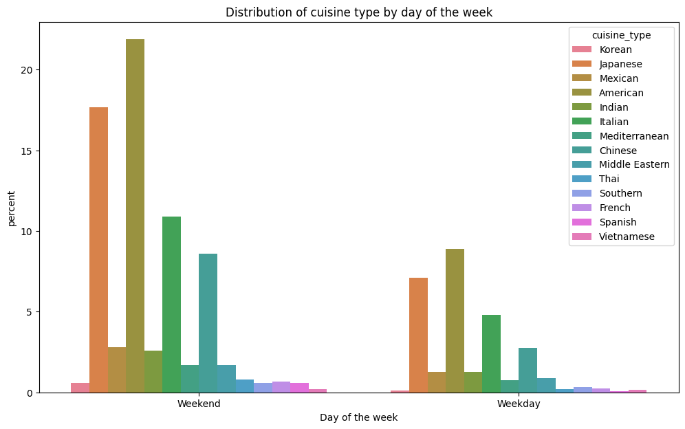

```python
# Examining the relation between cuisine_type and day_of_the_week
plt.figure(figsize=(12,7))
sns.countplot(df, x='day_of_the_week', hue='cuisine_type', stat='percent')
plt.xlabel('Day of the week')
plt.title('Distribution of cuisine type by day of the week')
plt.show()
```

#### Observations:

- During weekend and weekday most of the customers preferred American, followed by Japanese.
- During weekday the least preferred cuisine type is Spanish, but during weekend the least preferred cuisine type is Vietnamese.

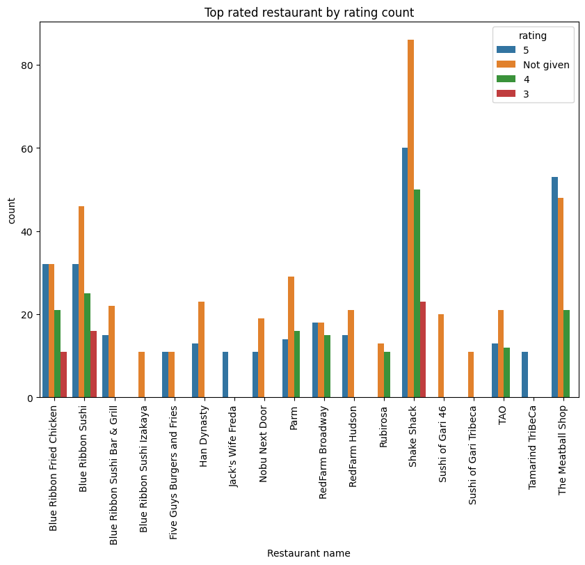

```python
# Extracting restaurants having rating count greater than 10
restaurant_counts = df.groupby(['restaurant_name'])['rating'].value_counts().reset_index()
filtered_rating_counts = restaurant_counts[restaurant_counts['count'] > 10].copy()

# Examining the most rated restaurant services
plt.figure(figsize=(10,7))
sns.barplot(filtered_rating_counts, x='restaurant_name', y='count', hue='rating')
plt.xlabel('Restaurant name')
plt.xticks(rotation=90)
plt.title('Top rated restaurant by rating count')
plt.show()
```

#### Observations:

- The below observations were based on filtered observations such that the restaurants were extracted have rating count greater than 10.
- Customers preferred mostly Shake Shack, followed by The Meatball shop restaurants.
- For Sushi of Gari Tribeca, Sushi of Gari 46 and Blue Ribbon Sushi Izakaya customers has not given any rating.
- Blue Ribbon Fried Chicken, Blue Ribbon Sushi and Shake Shack were only restaurants where the 3 rating was given.

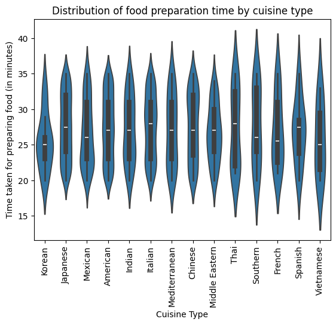

```python
# Examining the relation between cuisine_type and food_preparation_time
sns.violinplot(df, x='cuisine_type', y='food_preparation_time')
plt.xlabel('Cuisine Type')
plt.ylabel('Time taken for preparing food (in minutes)')
plt.xticks(rotation=90)
plt.title('Distribution of food preparation time by cuisine type')
plt.show()
```

#### Observations:

- Much inferences cannot be drawn from the relation between cuisine type and time taken for preparing food, since most of the restaurants were having a ready recipe and they are not taking more than 35 minutes.
- The minimum time taken for preparing food for most of the cuisine types is around 20 minutes. Except Thai and French which took around 21 minutes.
- The maximum time taken for preparing food for most of the cuisine types is around 35 minutes. Except for Korean, Middle Eastern and Vietnamese which is approximately 33 minutes, 34 minutes and 32 minutes approximately.

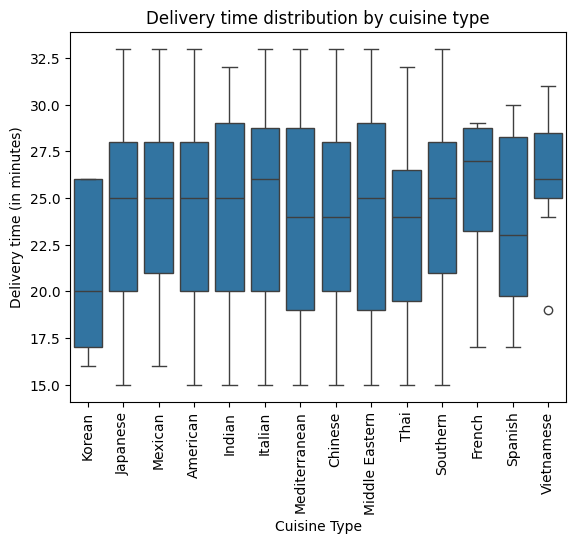

```python
# Examining the relation between cuisine_type and delivery_time
sns.boxplot(df, x='cuisine_type', y='delivery_time')
plt.xlabel('Cuisine Type')
plt.ylabel('Delivery time (in minutes)')
plt.xticks(rotation=90)
plt.title('Delivery time distribution by cuisine type')
plt.show()
```

#### Observations:

- Much inferences cannot be drawn from the relation between cuisine type and delivery time. Since time taken for delivering food is completely depened on the location of delivery, traffic but not on cuisine type.

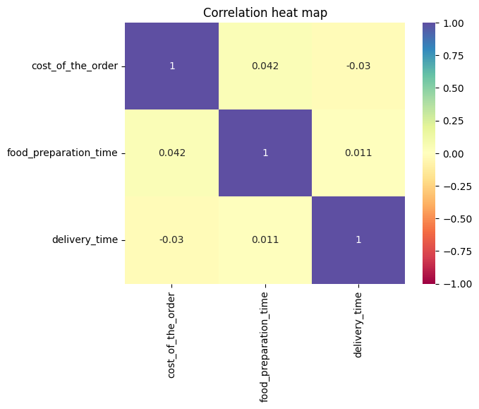

```python
# Heat map for examining correlation between the numerical variables
sns.heatmap(df[['cost_of_the_order', 'food_preparation_time', 'delivery_time']].corr(), annot=True, cmap='Spectral', vmin=-1, vmax=1)
plt.title('Correlation heat map')
plt.show()
```

#### Observations:

- Food preparation time and delivery time has a weak positive correlation.
- Cost of the order has weak positive correlation with food preparation time.
- Cost of the order has weak negative correlation with delivery time.

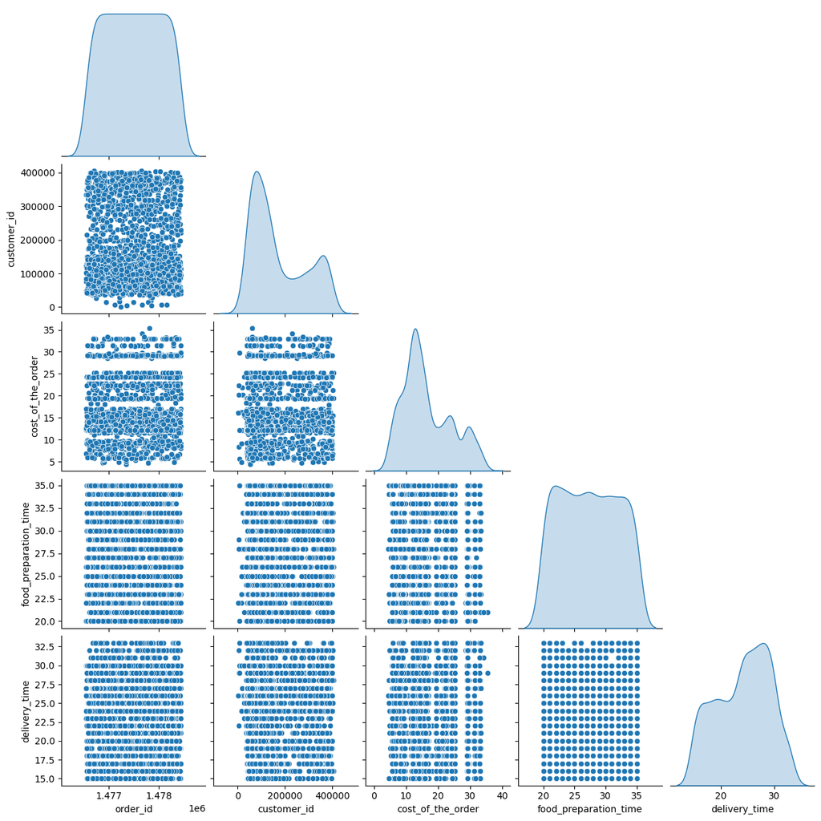

```python
# Pair plot between the numerical and categorical variables
plt.figure(figsize=(15,10))
sns.pairplot(df, diag_kind='kde', corner=True)
plt.show()
```

#### Observations:

- Much inferences cannot be drawn since, most of the influencing parameters has weak positive correlation.
- Time taken for preparing food has a slight skewness, but has an almost ideal distribution.
- The delivery time is left skewed.

### **Question 13:** The company wants to provide a promotional offer in the advertisement of the restaurants. The condition to get the offer is that the restaurants must have a rating count of more than 50 and the average rating should be greater than 4. Find the restaurants fulfilling the criteria to get the promotional offer. [3 marks]

```python
# filtering rated restaurants
rated = df[df['rating'] != 'Not given'].copy()

# converting data type of rating column from object to integer
rated['rating'] = rated['rating'].astype(int)

# rating count of the restaurants
rating_count = rated.groupby(['restaurant_name'])['rating'].count().reset_index()
# rename the column to rating count
rating_count.rename(columns={'rating': 'rating_count'}, inplace=True)

# restaurants having rating count more than 50
resta_names = rating_count[rating_count['rating_count']>50]

# mean rating of the restaurants
mean_rated = rated.groupby(['restaurant_name'])['rating'].mean().reset_index()
# rename the column to mean rated
mean_rated.rename(columns={'rating': 'mean_rated'}, inplace=True)

# restaurants having mean rating greater than 4
mean_4 = mean_rated[mean_rated['mean_rated']>4.0]

# Finding restaurants having rating count and mean greater than 50 and 4 respectively
promotional_offer = pd.merge(resta_names, mean_4, how='inner', on='restaurant_name')
# get the list of restaurant names
restaurant_names = promotional_offer['restaurant_name'].tolist()
restaurant_names

print(f'{restaurant_names[0]}, {restaurant_names[1]}, {restaurant_names[2]}, and {restaurant_names[3]} are eligible for promotional offer.')
print('-'*120)
promotional_offer
```

```
Blue Ribbon Fried Chicken, Blue Ribbon Sushi, Shake Shack, and The Meatball Shop are eligible for promotional offer.
------------------------------------------------------------------------------------------------------------------------
```

|  | restaurant_name | rating_count | mean_rated |
| --- | --- | --- | --- |
| 0 | Blue Ribbon Fried Chicken | 64 | 4.33 |
| 1 | Blue Ribbon Sushi | 73 | 4.22 |
| 2 | Shake Shack | 133 | 4.28 |
| 3 | The Meatball Shop | 84 | 4.51 |

#### Observations:

- There are 4 restaurants which were satisfying the criteria for promotional offer:
  1. Blue Ribbon Fried Chicken
  2. Blue Ribbon Sushi
  3. Shake Shack
  4. The Meatball Shop
- Even though the rating count for Shake Shack restaurant is more but it has an average rating of 4.28.
- The Meatball Shop has less rating count when compared with Shake Shack but the average rating is higher i.e., of 4.51.

### **Question 14:** The company charges the restaurant 25% on the orders having cost greater than 20 dollars and 15% on the orders having cost greater than 5 dollars. Find the net revenue generated by the company across all orders. [3 marks]

```python
# company charges on the orders
def company_charges(cost):
  if cost > 20:
    return cost*0.25
  elif cost > 5 and cost <= 20:
    return cost*0.15
  else:
    return cost*0

# calculate revenue generated on each cost of the order
df['revenue'] = df['cost_of_the_order'].apply(company_charges)

# Total revenue generated
total_revenue= df['revenue'].sum()
print(f'Total revenue generated by the restaurant is ${total_revenue:.2f}')
```

```
Total revenue generated by the restaurant is $6166.30
```

#### Observations:

- The net revenue of 6,166.3 dollars is being generated by the company across all orders.
- The FoodHub company should run some promotional events to increase the user engagement which in-turn impacts the revenue.

### **Question 15:** The company wants to analyze the total time required to deliver the food. What percentage of orders take more than 60 minutes to get delivered from the time the order is placed? (The food has to be prepared and then delivered.) [2 marks]

```python
# total time taken for the order to be delivered from the moment the order placed
df['total_time'] = df['food_preparation_time'] + df['delivery_time']

# calculate percentage for the orders that took 60 minutes to deliver
percent_60 = (df[df['total_time']>60]['delivery_time'].count()/df.shape[0])*100

print(f'{percent_60:.2f}% of the orders took more than 60 minutes to get delivered from the time the order placed.')
```

```
10.54% of the orders took more than 60 minutes to get delivered from the time the order placed.
```

#### Observations:

- An approximate of 10.54% of order takes more than 60 minutes to get delivered from the time the order is placed.
- Approximately 89.46% of orders were delivered within 60 minutes.

### **Question 16:** The company wants to analyze the delivery time of the orders on weekdays and weekends. How does the mean delivery time vary during weekdays and weekends? [2 marks]

```python
# Analyzing mean delivery time of orders during weekdays and weekends
mean_day_of_week_delivery = df.groupby('day_of_the_week')['delivery_time'].mean().reset_index()

# converting day of week to list
dow = mean_day_of_week_delivery['day_of_the_week'].tolist()

# converting delivery time to list
deliv_time = mean_day_of_week_delivery['delivery_time'].tolist()

print(f'The average delivery time during {dow[0]} is {deliv_time[0]:.2f} minutes and during {dow[1]} it is taking {deliv_time[1]:.2f} minutes')
print('-'*107)
mean_day_of_week_delivery
```

```
The average delivery time during Weekday is 28.34 minutes and during Weekend it is taking 22.47 minutes
-----------------------------------------------------------------------------------------------------------
```

|  | day_of_the_week | delivery_time |
| --- | --- | --- |
| 0 | Weekday | 28.34 |
| 1 | Weekend | 22.47 |

#### Observations:

- The mean delivery time during weekday is around 28.34 minutes and during weekend is around 22.47 minutes.
- During weekday the mean delivery time is greater when compared with weekend, this may be due to traffic and availability of delivery partner.

# Understanding based on Revenue

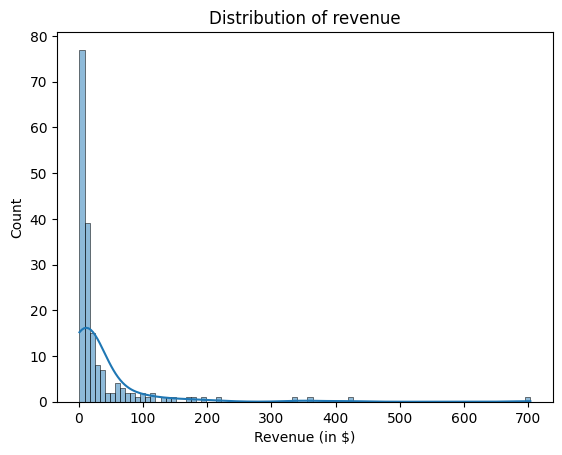

```python
# Extracting restaurants based on total revenue
restaurant_revenue = df.groupby(['restaurant_name'])['revenue'].sum().reset_index()

# Observation on revenue generated by the company
sns.histplot(restaurant_revenue, x='revenue', kde=True)
plt.xlabel('Revenue (in $)')
plt.title('Distribution of revenue')
plt.show()
```

#### Observations:

- Most of the restaurants generating revenue between 1 dollar to 30 dollars.
- The highest revenue generated is around 700 dollars.
- The revenue is right skewed.

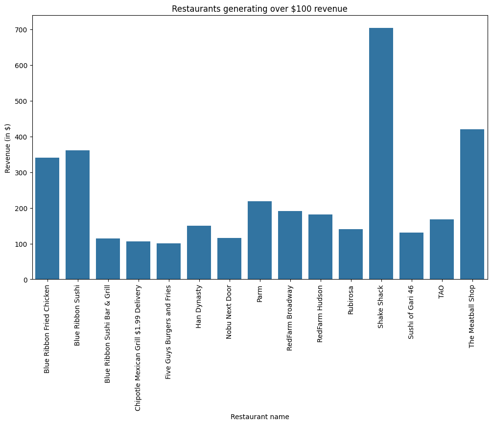

```python
# Extracting restaurants having revenue more than 100 dollars
revenue_more_100 = restaurant_revenue[restaurant_revenue['revenue'] >= 100].copy()

# Examining the restaurants generating more revenue to the food_hub company
plt.figure(figsize=(12,7))
sns.barplot(revenue_more_100, x='restaurant_name', y='revenue')
plt.xlabel('Restaurant name')
plt.ylabel('Revenue (in $)')
plt.xticks(rotation=90)
plt.title('Restaurants generating over $100 revenue')
plt.show()
```

#### Observations:

- Shake Shack is the highest revenue generated restaurant which is around 700 dollars. Followed by The Meatball Shop which is generating around 410 dollars.

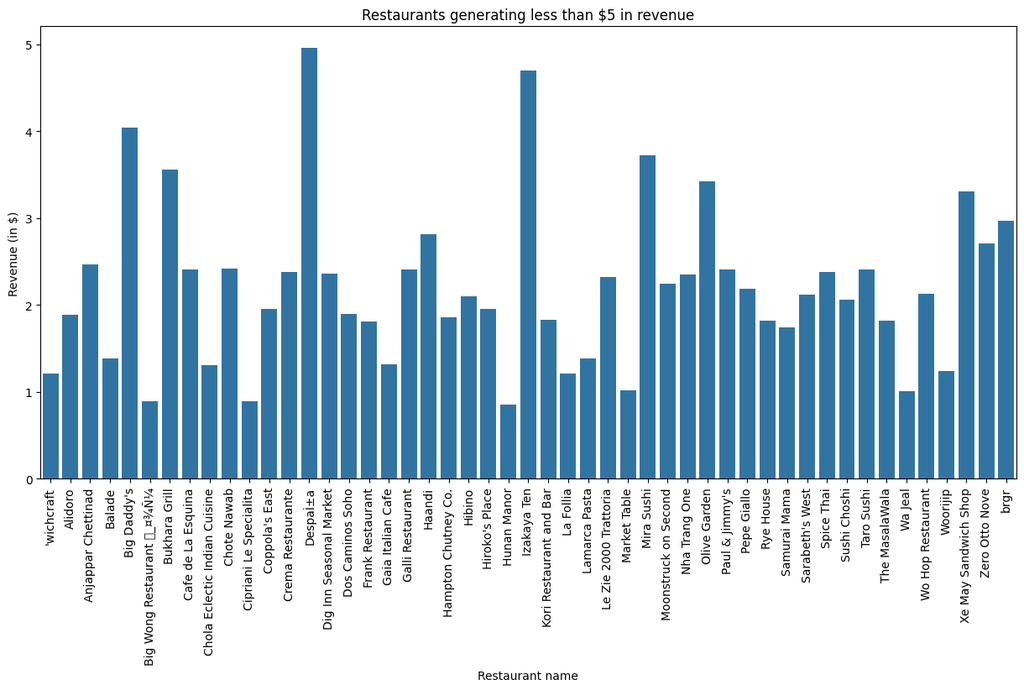

```python
# Extracting restaurants having revenue less than 5 dollars
revenue_less_5 = restaurant_revenue[restaurant_revenue['revenue'] < 5].copy()

# Examining the restaurants generating less revenue to the food_hub company
plt.figure(figsize=(15,7))
sns.barplot(revenue_less_5, x='restaurant_name', y='revenue')
plt.xlabel('Restaurant name')
plt.ylabel('Revenue (in $)')
plt.xticks(rotation=90)
plt.title('Restaurants generating less than $5 in revenue')
plt.show()
```

#### Observations:

- There are three restaurants that are generating less than 1 dollar as revenue to the company.
- Almost 49 restaurants were generating revenue less than 5 dollars.

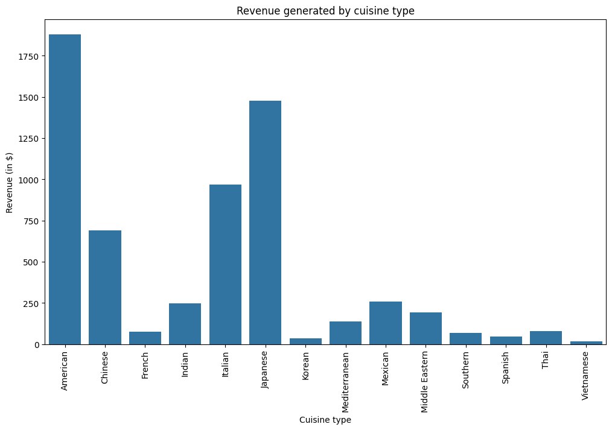

```python
# Calculating total revenue earned based on cuisine type
cuisine_revenue = df.groupby(['cuisine_type'])['revenue'].sum().reset_index()

# Examining revenue earned by the foodhub company based on cuisine type
plt.figure(figsize=(12,7))
sns.barplot(cuisine_revenue, x='cuisine_type', y='revenue')
plt.xlabel('Cuisine type')
plt.ylabel('Revenue (in $)')
plt.xticks(rotation=90)
plt.title('Revenue generated by cuisine type')
plt.show()
```

#### Observations:

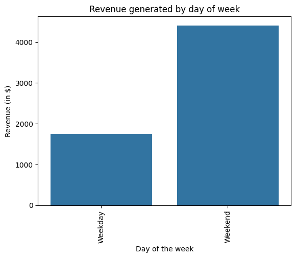

```python
# Calculating total revenue earned based on day_of_the_week
cuisine_revenue = df.groupby(['day_of_the_week'])['revenue'].sum().reset_index()

# Examining revenue earned by the foodhub company based on day_of_the_week
sns.barplot(cuisine_revenue, x='day_of_the_week', y='revenue')
plt.xlabel('Day of the week')
plt.ylabel('Revenue (in $)')
plt.xticks(rotation=90)
plt.title('Revenue generated by day of week')
plt.show()
```

### Recommendations:

- Strong partnership should be built with top revenue contributing restaurants such as Shake Shack, The Meatball Shop etc.
- Some flash promotional offers are recommended during weekday, so that volume of orders might increase, which in-turn increases the revenue.
- During weekdays time taken for delivering food is more, drone delivery services or increase of delivery agents should be considered.
- It is better to initiate some promotional offers on the most preferred cuisine types such as American, Japanese etc., to increase the customer engagement.
- The customer engagement towards the delivery service feed-back must be improved by using pre-populated information, In-app prompts, SMS and Email services, attaching some QR-code on delivered products.
- Promotional and marketing support can be considered for restaurants which are generating less revenue.
- Loyal customers must be awarded with some rewards or special discounts during their birthday's, wedding aniversary etc.